# Project4

In this project, you are going to explore matrix factorization methods for recommender system. The goal is to match consumers with most appropriate products. Matrix factorization methods characterize both items and users by vectors of factors inferred from item rating patterns. High correspondence between item and user factors leads to a recommendation. Matrix factorization generally has 3 parts:

- factorization algorithm
- regularization
- postpocessing

### Step 1 Load Data and Train-test Split

```r
data <- read.csv("../data/ml-latest-small/ratings.csv")

test_idx <- sample(1:nrow(data), round(nrow(data)/5, 0))
train_idx <- setdiff(1:nrow(data), test_idx)
data_train <- data[train_idx,]
data_test <- data[test_idx,]
```

### Step 2 Matrix Factorization

### Step 2.1 Algorithm and Regularization

Here I perform stochastic gradien descent to do matrix factorization. Your algorithm should consider case that there are new users and movies adding to the dataset you used to train. In other words, the dimension your matrix R, q, p is dynamic.

- For algorithms, the referenced paper are:

A1. Stochastic Gradient Descent Section: Learning Algorithms-Stochastic Gradient Descent

A2. Gradient Descent with Probabilistic Assumptions Section 2

A3. Alternating Least Squares Section 3.1

- For regularizations, the referenced paper are:

R1. Penalty of Magnitudes Section: a Basic Matrix Factorization Model

R2. Bias and Intercepts Section: Adding Biases

R3. Temporal Dynamics

```r
U <- length(unique(data$userId))
I <- length(unique(data$movieId))
source("../lib/Matrix_Factorization.R")
```

```r
result2 <- gradesc(f = 40, lambda = 0.3,lrate = 0.01, max.iter = 100, stopping.deriv = 0.01,
                   data = data, train = data_train, test = data_test)
save(result2, file = "../output/mat_fac.RData")
```

### Step 3 Postprocessing

After matrix factorization, postporcessing will be performed to improve accuracy. The referenced papers are:

P1:Global bias correction Section 4.1

P2:Postprocessing SVD with KNN Section 3.5

P3:Postprocessing SVD with kernel ridge regression Section 3.6

P4:Linearly combination of predictors Section 4.1

```r
load(file = "../output/mat_fac.RData")
est_rating <- t(result2$q) %*% result2$p
extract_est_rating <- function(test_set, est){
  est_rating <- est[as.character(test_set[2]), as.character(test_set[1])]
  return(est_rating)
}

est_test_rating <- apply(data_test, 1, extract_est_rating, est_rating)
est_mean <- mean(est_test_rating)
mean_test_rating <- mean(data_test$rating)
data_test$pred <- est_test_rating

mean_diff <- mean_test_rating - est_mean
data_test$pred_adj <- est_test_rating + mean_diff

boxplot(data_test$pred_adj ~ data_test$rating)
rmse_adj <- sqrt(mean((data_test$rating - data_test$pred_adj)^2))
```

[output not shown]

```r
est_mean <- mean(apply(data_train, 1, extract_est_rating, est_rating))
mean_train_rating <- mean(data_train$rating)
data_train$pred <- apply(data_train, 1, extract_est_rating, est_rating)
cov(data_train$rating, data_train$pred)
plot(data_train$rating, data_train$pred)
```

[output not shown]

### Step 4 Evaluation

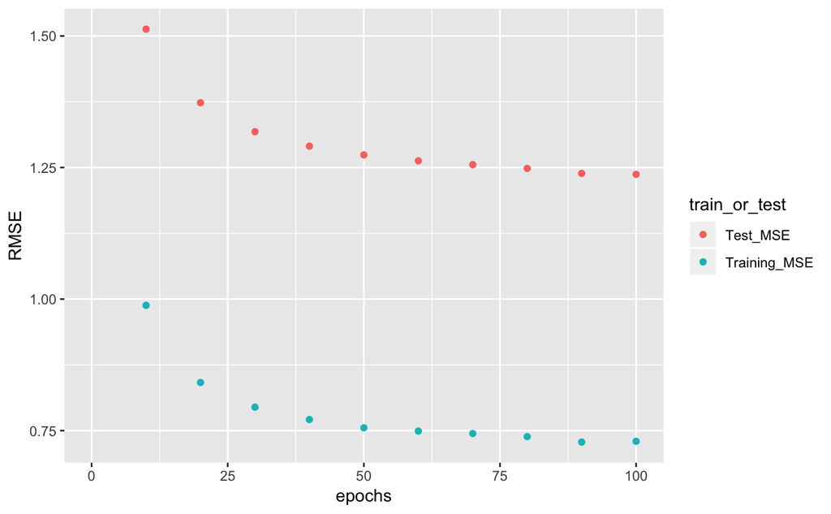

```r
library(ggplot2)
RMSE <- data.frame(epochs = seq(10, 100, 10), Training_MSE = result2$train_rmse, Test_MSE = result2$test_rmse) %>% gather(key = train_or_test, value = RMSE, -epochs)
RMSE %>% ggplot(aes(x = epochs, y = RMSE,col = train_or_test)) + geom_point() + scale_x_discrete(limits = seq(10, 100, 10)) + xlim(c(0, 100))
```